# Instructions:

[figure not shown]

https://www.kaggle.com/c/intel-mobileodt-cervical-cancer-screening/

https://www.kaggle.com/ofriharel/224-224-cervical-cancer-screening

[figure not shown]

[timm library](https://rwightman.github.io/pytorch-image-models/)

[figure not shown]

https://github.com/rwightman/pytorch-image-models

https://www.kaggle.com/c/intel-mobileodt-cervical-cancer-screening/

# Preperatory Report:

## NN Architectures

### 1.ResNet 50

ResNet enables us to train very deep networks, by enabling the network to skip layers that it thinks are unnecessary.

Each ResNet block is either two layers deep (used in small networks like ResNet 18, 34) or 3 layers deep (ResNet 50, 101, 152).

50-layer ResNet: Each 2-layer block is replaced in the 34-layer net with this 3-layer bottleneck block, resulting in a 50-layer ResNet. This model has 3.8 billion FLOPs.

Benefits:

[figure not shown]

Deficits

1. it takes alot of memory. even layers that eventually would do nothing, will still be sitting in the RAM
2. More Calculations in forward pass & backprop
3. Slower Reference

[figure not shown]

Gated Highway (a type of residual)

[figure not shown]

### 2.EfficieNet 3

[Source Video](https://www.youtube.com/watch?v=3svIm5UC94I&ab_channel=HenryAILabs)

[Source Paper](https://towardsdatascience.com/googles-efficientdet-an-overview-8d010fa15860)

Optimize for accuracy, but punish hard for computational complexity & for slow inference time

EfficientNet is a way to scale-up neural networks when balancing the Width, Depth & input Resolution.

Usualy we'll want to scale up when we're underfitting

There are manny ways to scale up Convolution NN:

1. #of layers of our model
2. #of Width of certain layers
3. #of input resolution of the input images

[figure not shown]

As we scale up along a single dimension, the accuracy will start to improve. but will quickly saturate. **Our goal is to scale up in these 3 compound togther, in the best possible way**

[figure not shown]

(r=1 is original image 224x224, r=2 is double: 448x448)

**We will optimize the network subject to max computational resources:**

[figure not shown]

- phi - Increase in computational resources. 2^phi more computational res
- alpha, Beta, Gamma are constant coefficients determained by GRID SEARCH on the ogirinal model

benefits:

1. Balance all dimensions of network width/depth/resolution
2. Computational complexity
3. Inference time
4. Less parameters

[figure not shown]

Deficits

1. if the input image is bigger -> network needs more layers to increase it's receptive field & more channels to capture more fine-grained patterns

(Reminder, Perceptive view)

[figure not shown]

### 3.Inception - v4

Inception model is used in the GoogLent

[Video- Justin Johnson 0:40:00](https://www.youtube.com/watch?v=XaZIlVrIO-Q&list=PL5-TkQAfAZFbzxjBHtzdVCWE0Zbhomg7r&index=8&ab_channel=MichiganOnline)

[vid2](https://www.youtube.com/watch?v=DAOcjicFr1Y&t=1531s&ab_channel=StanfordUniversitySchoolofEngineering)

Why choosing? for each conv layer we'll do all kinds of convolution! Then concatenate all the outputs and let the network learn which parameters it wants to use, which combination of these filter sizes it wants.

[figure not shown]

Benefits:

1. Very accuarate:

[figure not shown]

Defecits:

1. Computational cost since it is very expensive to calculate, there was a workaround which includes 1x1 filter b4 calc 3x3 and 5x5:

[figure not shown]

Inception V2 - Batch Normalization

[figure not shown]

Inception V3 - Factorization:

[figure not shown]

Example: By using 3×3 filter, number of parameters = 3×3=9 By using 3×1 and 1×3 filters, number of parameters = 3×1+1×3=6 Number of parameters is reduced by 33%

Inception V4

A more uniform simplified architecture and more inception modules than Inception-v3, is introduced as below:

[figure not shown]

[Towards Data Sience Article](https://towardsdatascience.com/review-inception-v4-evolved-from-googlenet-merged-with-resnet-idea-image-classification-5e8c339d18bc)

This is a pure Inception variant without any residual connections. It can be trained without partitioning the replicas, with memory optimization to backpropagation.

We can see that the techniques from Inception-v1 to Inception-v3 are used. (Batch Normalization is also used but not shown in the figure.)

### 4.MobileNet V3

[arxiv Paper](https://arxiv.org/abs/1905.02244)

MobileNetV3 is tuned to mobile phone CPUs through a combination of hardware-aware network architecture search (NAS) complemented by the NetAdapt algorithm, These models applied to the tasks of object detection and semantic segmentation

MobileNetV3-Large detection is 25\% faster at roughly the same accuracy as MobileNetV2 on COCO detection. MobileNetV3-Large LR-ASPP is 30\% faster than MobileNetV2 R-ASPP at similar accuracy for Cityscapes segmentation.

MobileNetV3 helps preserve battery life through reduced power consumption

[figure not shown]

## Files I/O

### GitHub I/O

```python
import os
import pickle
from pathlib import Path
from datetime import datetime
from datetime import date
import random
from sklearn.model_selection import train_test_split

now = datetime.now()
current_time = now.strftime("%H:%M:%S")



# Setup Constants
GIT_NEW_BRANCH_NAME = f'Lab8: {date.today()} at {current_time}'
GIT_DEFAULT_BRANCH_NAME = 'main'
GIT_USER_NAME = 'Shahar Raz'
GIT_USER_EMAIL = 'SRazStudent@gmail.com'
GIT_DEFAULT_MESSAGE = f'{GIT_USER_NAME}, {date.today()} at {current_time}'

!git init

def importFilesFromGithub(branch_name = GIT_DEFAULT_BRANCH_NAME):
    """returns the directory in-which we'll save the files"""

    # if not already imported
    if not Path("/content/ComputerVision2021B").exists():
        # add the new remote (with id key)
        ! git remote add CV2021Github https://github.com/ShahaRaz/ComputerVision2021B.git
        # create new local directory
        ! mkdir ComputerVision2021B/
        # pulling project to local dir
        ! git --work-tree=/content/ComputerVision2021B/ pull CV2021Github $branch_name;

    return r'/content/ComputerVision2021B/Assignment/Assignment2'



def saveFilesToGithub(message_of_commit = GIT_DEFAULT_MESSAGE,branch_name = GIT_NEW_BRANCH_NAME, user_name = GIT_USER_NAME, user_email = GIT_USER_EMAIL):
    def setLocalID():
        # adding my name
        !git config --global user.name  user_name   #"Shahar  "
        !git config --global user.email user_email  #"SRazStudent@gmail.com"
        #__ changing use name: __
        # !git config --global --unset user.name
        # !git config --global user.name  "Shahar ModifiedName "
                        # list configs
                        # !git config -l

    setLocalID()

    # create new branch
    if branch_name is not GIT_DEFAULT_BRANCH_NAME:
        !git checkout -b $branch_name

    # add files to commit
    !git add /content/ComputerVision2021B/*
                    # #checking the status
                    # !git status


    # Commit all Changes
    !git commit -a -m message_of_commit #"delete meee"

    # Push to remote
    !git push CV2021Github $branch_name #master


directory = importFilesFromGithub()
```

```
Initialized empty Git repository in /content/.git/
remote: Enumerating objects: 228, done.
remote: Counting objects: 100% (228/228), done.
remote: Compressing objects: 100% (201/201), done.
remote: Total 228 (delta 33), reused 118 (delta 5), pack-reused 0
Receiving objects: 100% (228/228), 87.51 MiB | 30.39 MiB/s, done.
Resolving deltas: 100% (33/33), done.
From https://github.com/ShahaRaz/ComputerVision2021B
 * branch            main       -> FETCH_HEAD
 * [new branch]      main       -> CV2021Github/main
```

### Kaggle I/O

[Video Tutorial](https://www.youtube.com/watch?v=gkEbaMgvLs8&ab_channel=DecisionForest)

[Written Tutorial](https://towardsdatascience.com/a-quicker-way-to-download-kaggle-datasets-in-google-collab-abe90bf8c866)

```python
!pip install --upgrade --force-reinstall --no-deps kaggle
```

```
     |████████████████████████████████| 61kB 5.7MB/s
  Found existing installation: kaggle 1.5.12
    Uninstalling kaggle-1.5.12:
      Successfully uninstalled kaggle-1.5.12
```

```python
!kaggle -v
```

[output not shown]

```python
# create new directory from root
!mkdir -p ~/.kaggle

# copy the token file
!cp "/content/ComputerVision2021B/Lab Reports/Lab8/kaggle_deleteme.json" ~/.kaggle/

# Check the file in its new directory
!ls /root/.kaggle/

# rename file for proper format
!mv ~/.kaggle/kaggle_deleteme.json ~/.kaggle/kaggle.json

# Check the file permission
!ls -l ~/.kaggle/kaggle.json

#Change the file permission
# chmod 600 file – owner can read and write
# chmod 700 file – owner can read, write and execute
!chmod 600 ~/.kaggle/kaggle.json






# !pip install -q kaggle
# !pip install -q kaggle-cli
# !mkdir -p ~/.kaggle
# !cp "your/path/to/kag gle.json" ~/.kaggle/
# !cat ~/.kaggle/kaggle.json
# !chmod 600 ~/.kaggle/kaggle.json
```

```
kaggle_deleteme.json
-rw-r--r-- 1 root root 64 May  2 12:19 /root/.kaggle/kaggle.json
```

```python
!mkdir data/

# when using % instead of !, it acctually stepping and stays there.
%cd data/

!ls

!pwd # Present Working Directory

!kaggle datasets download -d ofriharel/224-224-cervical-cancer-screening
```

[output not shown]

```python
# when using % instead of !, it acctually stepping and stays there.
%cd data/
```

```
/content/data
```

```python
!ls
```

```python
!pwd # Present Working Directory
```

```
/content/data
```

```python
!kaggle datasets download -d ofriharel/224-224-cervical-cancer-screening
```

```
Downloading 224-224-cervical-cancer-screening.zip to /content/data
 97% 192M/198M [00:02<00:00, 71.7MB/s]
100% 198M/198M [00:02<00:00, 82.8MB/s]
```

## Train Model

```python
!nvidia-smi
```

```
Sun May  2 12:19:29 2021
+-----------------------------------------------------------------------------+
| NVIDIA-SMI 465.19.01    Driver Version: 460.32.03    CUDA Version: 11.2     |
|-------------------------------+----------------------+----------------------+
| GPU  Name        Persistence-M| Bus-Id        Disp.A | Volatile Uncorr. ECC |
| Fan  Temp  Perf  Pwr:Usage/Cap|         Memory-Usage | GPU-Util  Compute M. |
|                               |                      |               MIG M. |
|===============================+======================+======================|
|   0  Tesla P100-PCIE...  Off  | 00000000:00:04.0 Off |                    0 |
| N/A   33C    P0    26W / 250W |      0MiB / 16280MiB |      0%      Default |
|                               |                      |                  N/A |
+-------------------------------+----------------------+----------------------+

+-----------------------------------------------------------------------------+
| Processes:                                                                  |
|  GPU   GI   CI        PID   Type   Process name                  GPU Memory |
|        ID   ID                                                   Usage      |
|=============================================================================|
|  No running processes found                                                 |
+-----------------------------------------------------------------------------+
```

#### Imports

```python
from matplotlib import pyplot as plt
import numpy as np

import keras
from keras.datasets import mnist
(x_train, y_train), (x_test, y_test) = mnist.load_data()

import cv2
from scipy.signal import convolve, convolve2d
import math
from sklearn.model_selection import train_test_split
```

```
Downloading data from https://storage.googleapis.com/tensorflow/tf-keras-datasets/mnist.npz
```

### 1. Prepair Data

[unzipping data](https://stackoverflow.com/questions/49685924/extract-google-drive-zip-from-google-colab-notebook)

```python
!ls
```

```
224-224-cervical-cancer-screening.zip
```

```python
# Unzipping the data
# !apt install unzip
import os
import pickle
from pathlib import Path

# if not already imported
if not Path("/content/data/kaggle/").exists():
    # !mkdir "/content/data/"
    !unzip -uq "/content/data/224-224-cervical-cancer-screening.zip" -d "/content/data"
    # !unzip archive.zip -d /content/data/


PATH_TO_FILES = '/content/data/kaggle'
# Get back to default directory.
%cd /content
```

```
/content
```

#### 1.1 Dataset Class

```python
class LoadPathsFromDisk:
    def __init__(self, path_to_images_folder):
        """
        __folders will contain:__
        additional_Type_1_v2
        additional_Type_2_v2
        additional_Type_3_v2
        test
        test_stg2
        train
        """
        # self.path_to_images_folder = path_to_images_folder
        self.original_imgs_train = []
        self.original_imgs_test = []

        directories = {}
        directories['Type1'] = '/content/data/kaggle/additional_Type_1_v2/Type_1'
        directories['Type2'] ='/content/data/kaggle/additional_Type_2_v2/Type_2'
        directories['Type3'] = '/content/data/kaggle/additional_Type_3_v2/Type_3'
        directories['test'] = '/content/data/kaggle/test/test'
        directories['test2'] = '/content/data/kaggle/test_stg2'
        directories['TRAIN_Type1'] = '/content/data/kaggle/train/train/Type_1'
        directories['TRAIN_Type2'] = '/content/data/kaggle/train/train/Type_2'
        directories['TRAIN_Type3'] = '/content/data/kaggle/train/train/Type_3'

        # get file names in each directory
        for data_name, dir in directories.items():

            for photo_path in os.listdir(dir):
                full_photo_path = os.path.join(dir, photo_path)
                if os.path.isfile(full_photo_path):

                    #test images:
                    if 'test' in data_name:
                        self.original_imgs_test.append(full_photo_path)

                    # train images
                    else:
                        self.original_imgs_train.append((full_photo_path, data_name))


        # for dir in directories.values():
        #     os.listdir(dir):
        #         for i in range(0,len(filenames)):
        #             path_to_image = f'{path_to_images_folder}/{data_name}/{filenames[i]}'
        #             self.original_imgs.append((path_to_image, data_name))


    def load_data(self, perc_validation=0.2):

        # Convert to NP.ndarray
        self.original_imgs_train = np.asarray(self.original_imgs_train)


        # split X-y
        X, y = self.original_imgs_train[:, 0], self.original_imgs_train[:, 1]



        # train_test_split shuffles the data
        X_train, X_valid, y_train, y_valid = train_test_split(X, y, test_size = perc_validation)

        return (X_train, y_train), (X_valid, y_valid)

    def load_test(self):
        return self.original_imgs_test



    @staticmethod
    def split_dataset_3way(X, y,validation_size = 0.30 ,test_size = 0.10):
        """Will Split the data to Train, Test and Validation  """
        # for example: 90% to training [= 0.1]
        if test_size > 0:
            X_train, X_test, y_train, y_test = train_test_split(X, y, test_size = test_size)
        # from that 90%, 10% will go to [ validation = 0.1 ]
        if validation_size > 0 :
            X_train, X_validation, y_train, y_validation = train_test_split(X_train, y_train, test_size = validation_size)
        # will leave us with:
        # 10% - Test
        # 81% - Train
        # 9% - Validation
        return X_train, X_validation, X_test, y_train, y_validation, y_test
```

#### 1.2 Present the images & split

```
6132 6132 1533 1533
```

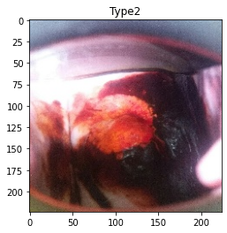

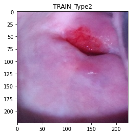

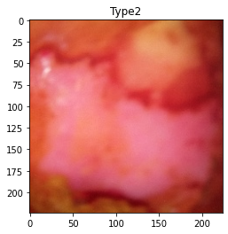

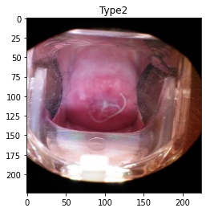

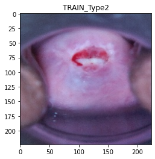

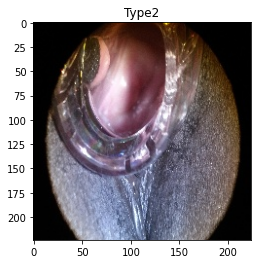

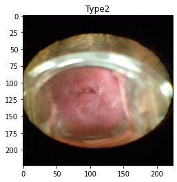

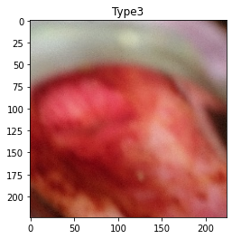

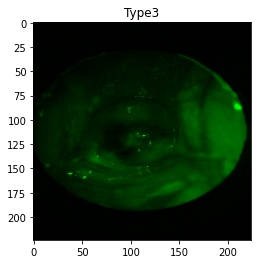

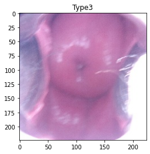

```python
photos_directory = f'{PATH_TO_FILES}'
data = LoadPathsFromDisk(photos_directory)


(X_train, y_train), (X_valid, y_valid) = data.load_data()
print(len(X_train), len(y_train), len(X_valid), len(y_valid))

for image, lbl, limiter in zip(X_train, y_train, range(0,500,50)):
    plt.imshow(cv2.cvtColor(cv2.imread(image), cv2.COLOR_BGR2RGB))
    plt.title(lbl)
    plt.show()
```

#### 1.3 Dataloader From Disk W/ Augmentations

```python
from torch.utils.data import Dataset, DataLoader
import torch
import albumentations as A

class CancerDetectionDataset(Dataset):
    def __init__(self, x_train, y_train, transforms=None):
        super (CancerDetectionDataset, self).__init__()
        self.x_train = x_train
        self.y_train = y_train
        self.transform = transforms

    def __getitem__(self,idx):
        assert isinstance(idx, (int))
        if idx < len(self.x_train):
            print(self.x_train[idx])
            img = cv2.imread(self.x_train[idx])
            img = cv2.cvtColor(img, cv2.COLOR_BGR2RGB)
            # img = pil2np(self.x_train[idx])
            label = self.y_train[idx]
            if self.transform:
                img = self.transform(image=img)["image"]
            img = (img.astype(np.float) )/ img.max() # normlize values to [0,1]
            img = torch.tensor(img) #return as tensor object (for future )
            return (img, label)
        else:
            return -1

    def __len__(self):
        return len(self.x_train)
```

```
/content/data/kaggle/additional_Type_3_v2/Type_3/5319.jpg
```

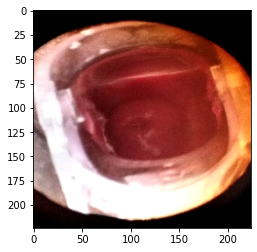

```python
transform = A.Compose([
    A.Rotate(limit=25.5, p = 0.6),
    A.Blur(blur_limit=3, p = 0.3),
    A.GaussNoise(p=0.2),
    A.RGBShift(p=0.151),
    A.CLAHE(p=0.3),
    A.RandomBrightness(p=0.6),
    A.RandomContrast(p=0.3),
    A.RandomGamma(p=0.4),
    A.ChannelShuffle(p=0.65)
])
imgs_cancer_dataset = CancerDetectionDataset(X_train, y_train, transform)
plt.imshow(imgs_cancer_dataset[60][0])
```

#### 1.4 DataLoader - Pytorch's

```
/content/data/kaggle/additional_Type_2_v2/Type_2/1382.jpg
```

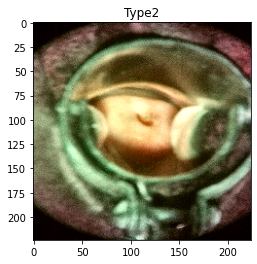

```
/content/data/kaggle/additional_Type_2_v2/Type_2/3967.jpg
```

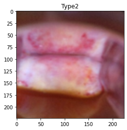

```
/content/data/kaggle/additional_Type_2_v2/Type_2/6313.jpg
```

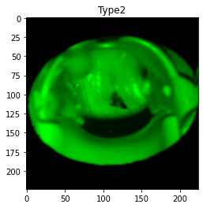

```
/content/data/kaggle/additional_Type_3_v2/Type_3/5572.jpg
```

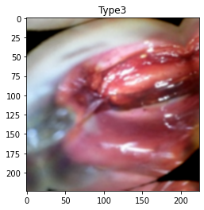

```
/content/data/kaggle/additional_Type_2_v2/Type_2/2146.jpg
```

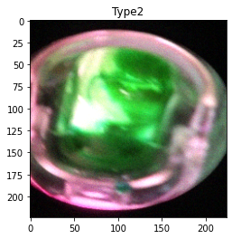

```
/content/data/kaggle/additional_Type_3_v2/Type_3/1683.jpg
```

```python
batch_size = 1
trainloader = DataLoader(imgs_cancer_dataset, batch_size=batch_size, shuffle=True)
for (images, labels), limiter in zip(trainloader, range(0,500,100)):
    for i in range(batch_size):
        plt.imshow(images[i])
        plt.title(labels[i])
        plt.show()
```

### 2. Train Model:

```python
## CONSTANTS:
NUM_FINETUNE_CLASSES = 3 # Type1,2,3
## TODO: check again if a "no abnormality" is a category.
```

#### 2.1 Import Trained Models

```python
!pip install timm
```

```
     |████████████████████████████████| 296kB 7.8MB/s
```

```python
import timm
from pprint import pprint
model_names = timm.list_models(pretrained=True)
pprint(model_names)
```

[output not shown]

```python
# improt Trained models:

is_imported = False

def import_models(model1 = 'mobilenetv3_large_100', model2 = 'resnet50', model3 = 'efficientnet_b3', num_classes = NUM_FINETUNE_CLASSES ):

    m1_MobileNetV3 = timm.create_model(model1, pretrained=True, num_classes=NUM_FINETUNE_CLASSES)
    m1_MobileNetV3.eval()


    m2_ResNet50 = timm.create_model(model2, pretrained=True, num_classes=NUM_FINETUNE_CLASSES)
    m2_ResNet50.eval()


    m3_EfficientNet_B3 = timm.create_model(model3, pretrained=True, num_classes=NUM_FINETUNE_CLASSES)
    m3_EfficientNet_B3.eval()

    return m1_MobileNetV3, m2_ResNet50, m3_EfficientNet_B3

# import once only
if is_imported is False:
    m1_MobileNetV3, m2_ResNet50, m3_EfficientNet_B3 = import_models()
    is_imported = True
```

```
Downloading: "https://github.com/rwightman/pytorch-image-models/releases/download/v0.1-weights/mobilenetv3_large_100_ra-f55367f5.pth" to /root/.cache/torch/hub/checkpoints/mobilenetv3_large_100_ra-f55367f5.pth
Downloading: "https://github.com/rwightman/pytorch-image-models/releases/download/v0.1-weights/resnet50_ram-a26f946b.pth" to /root/.cache/torch/hub/checkpoints/resnet50_ram-a26f946b.pth
Downloading: "https://github.com/rwightman/pytorch-image-models/releases/download/v0.1-weights/efficientnet_b3_ra2-cf984f9c.pth" to /root/.cache/torch/hub/checkpoints/efficientnet_b3_ra2-cf984f9c.pth
```

#### 2.2 import TensorBoard

```python
from torch.utils.tensorboard import SummaryWriter
%load_ext tensorboard
%reload_ext tensorboard


experiment = 1
run = 0

writer_m1_MobileNetV3 = SummaryWriter(f'runs/m1_MobileNetV3_{experiment}')
writer_m2_ResNet50 = SummaryWriter(f'runs/m2_ResNet50 _{experiment}')
writer_m3_EfficientNet_B3 = SummaryWriter(f'runs/m3_EfficientNet_B3_{experiment}')
```

```python
%tensorboard --logdir=runs
```

#### 2.3

```python
import torchvision


dataiter = iter(trainloader)
images, labels = dataiter.next()

# create grid of images
img_grid = torchvision.utils.make_grid(images)

# show images
# matplotlib_imshow(img_grid, one_channel=False)

# write to tensorboard
run += 1
print(f'experiment: # {experiment}, iter:{run}')

writer_m1_MobileNetV3.add_image(f'#{run}. 4 images: {tuple(classes[label] for label in labels)}', img_grid)
```

```
/content/data/kaggle/additional_Type_2_v2/Type_2/3550.jpg
experiment: # 1, iter:2
```

[output not shown]

```python
print(f'type: {type(m1_MobileNetV3)}')
dir(m1_MobileNetV3)
```

```
type: <class 'timm.models.mobilenetv3.MobileNetV3'>
```

[output not shown]

[output cut: 52 more lines]

[output not shown]

```python
m1_MobileNetV3.train?
```